# BTS 510 Lab 13

```r
set.seed(12345)
library(tidyverse)
library(Stat2Data)
theme_set(theme_classic(base_size = 16))
```

## 1 Learning objectives

- **Conduct** analysis on time-to-event outcomes
  - Kaplan-Meier curve, proportional hazards regression
- **Describe** issues related to time-to-event analysis
  - Censoring, proportional hazards, time-varying predictors

## 2 Data

- `cancer` dataset in **survival** package
- n = 228 observations on 10 variables
  - `inst`: Institution code
  - `time`: Survival time in **days**
  - `status`: censoring status 1=censored, 2=dead
  - `age`: Age in years
  - `sex`: Male=1 Female=2
  - `ph.ecog`: ECOG performance score as rated by the physician. 0=asymptomatic, 1= symptomatic but completely ambulatory, 2= in bed <50% of the day, 3= in bed > 50% of the day but not bedbound, 4 = bedbound
  - `ph.karno`: Karnofsky performance score (bad=0-good=100) rated by physician
  - `pat.karno`: Karnofsky performance score as rated by patient
  - `meal.cal`: Calories consumed at meals
  - `wt.loss`: Weight loss in last six months (pounds)

## 3 Analysis

- Look more carefully at the last analysis from the lecture
  - `sex` and `age` predict survival time (`time` and `status`)
- Load packages and read in data

```r
library(survival)
library(ggsurvfit)
data(cancer)
```

- Look at the model

```r
cox2 <- coxph(Surv(time, status) ~ sex + age, data = cancer)
summary(cox2)
```

```
Call:
coxph(formula = Surv(time, status) ~ sex + age, data = cancer)

  n= 228, number of events= 165

         coef exp(coef)  se(coef)      z Pr(>|z|)
sex -0.513219  0.598566  0.167458 -3.065  0.00218 **
age  0.017045  1.017191  0.009223  1.848  0.06459 .
---
Signif. codes:  0 '***' 0.001 '**' 0.01 '*' 0.05 '.' 0.1 ' ' 1

    exp(coef) exp(-coef) lower .95 upper .95
sex    0.5986     1.6707    0.4311    0.8311
age    1.0172     0.9831    0.9990    1.0357

Concordance= 0.603  (se = 0.025 )
Likelihood ratio test= 14.12  on 2 df,   p=9e-04
Wald test            = 13.47  on 2 df,   p=0.001
Score (logrank) test = 13.72  on 2 df,   p=0.001
```

- Does the proportional hazards assumption hold for this model?

```r
cox.zph(cox2)
```

```
       chisq df    p
sex    2.608  1 0.11
age    0.209  1 0.65
GLOBAL 2.771  2 0.25
```

- `age` is continuous but let’s chop it up to look at this effect
  - `cut()` divides the variable based on the `breaks` and then calls each category by the names in `labels`
  - 4 values in `breaks` = 3 categories because they’re the cut-points, so `-Inf` to 50, 50 to 70, 70 to `Inf`

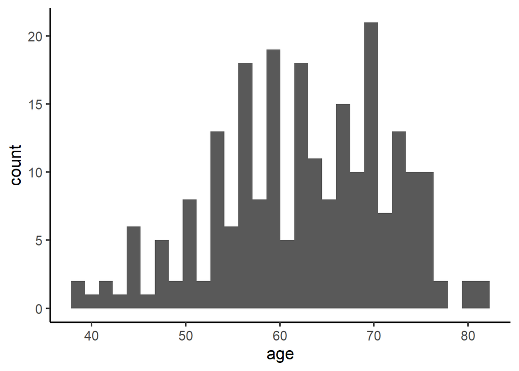

```r
ggplot(data = cancer, aes(x = age)) +
  geom_histogram()
```

```r
cancer <- cancer %>%
  mutate(age_group = cut(age,
                        breaks = c(-Inf, 50, 70, Inf),
                        labels = c(1, 2, 3)))
head(cancer)
```

```
  inst time status age sex ph.ecog ph.karno pat.karno meal.cal wt.loss
1    3  306      2  74   1       1       90       100     1175      NA
2    3  455      2  68   1       0       90        90     1225      15
3    3 1010      1  56   1       0       90        90       NA      15
4    5  210      2  57   1       1       90        60     1150      11
5    1  883      2  60   1       0      100        90       NA       0
6   12 1022      1  74   1       1       50        80      513       0
  age_group
1         3
2         2
3         2
4         2
5         2
6         3
```

- Kaplan-Meier curves for each effect (`sex` and `age_group`) separately

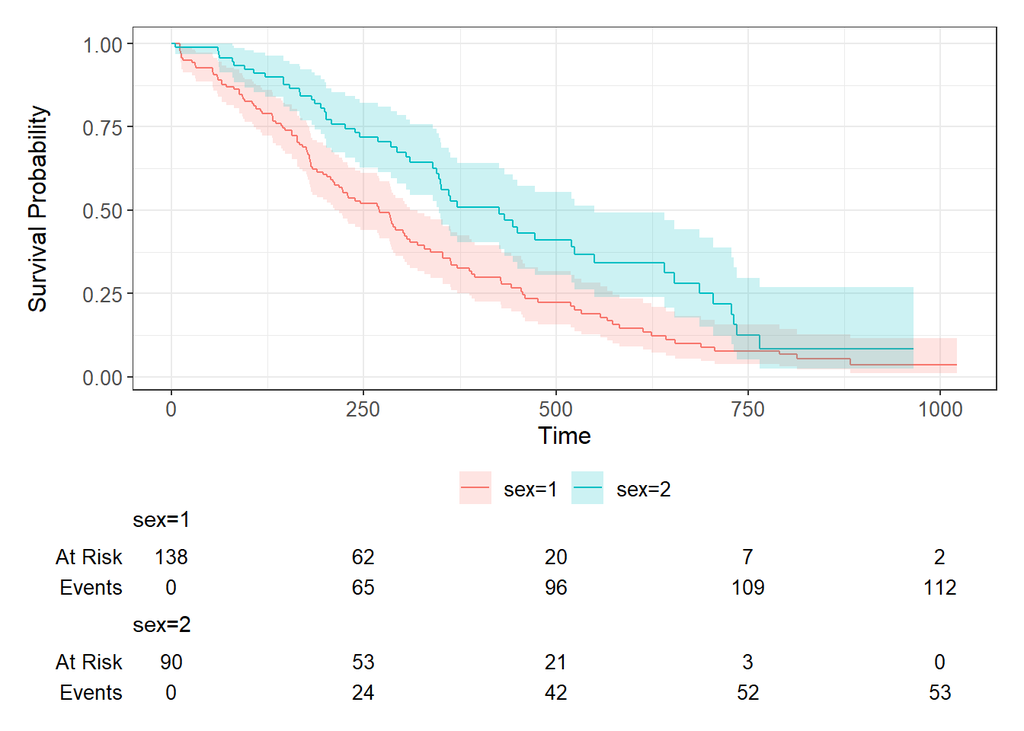

```r
sfit_sex <- survfit(Surv(time, status) ~ sex, data = cancer)
sfit_age <- survfit(Surv(time, status) ~ age_group, data = cancer)

ggsurvfit(sfit_sex) +
  add_confidence_interval() + add_risktable()
```

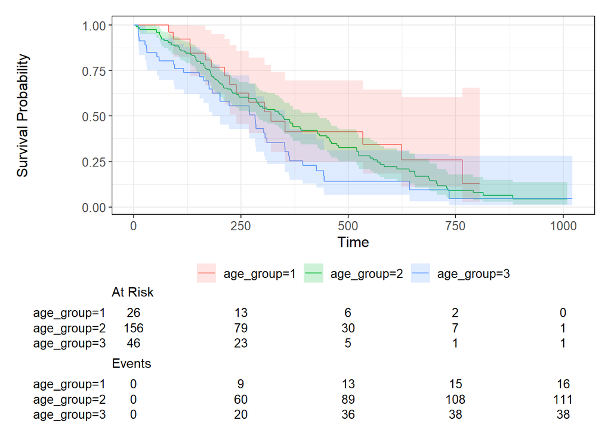

```r
ggsurvfit(sfit_age) +
  add_confidence_interval() + add_risktable()
```

## 4 Tasks

- Select another predictor in the dataset

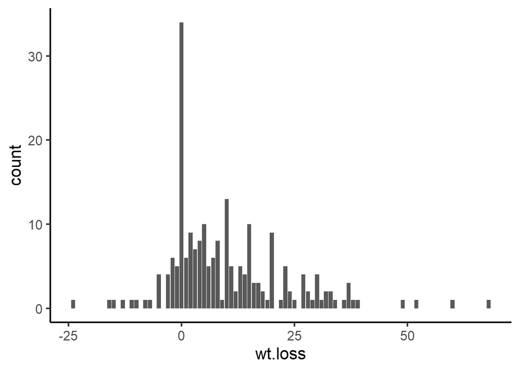

```r
ggplot(data = cancer, aes(x = wt.loss)) +
  geom_bar()
```

- Run a Cox regression model with that predictor
  - Report hazard ratios and their confidence intervals
    - Interpret the effects
  - Is the proportional hazards assumption satisfied?
    - If not, what are some time-varying covariates you might include?

```r
cox3 <- coxph(Surv(time, status) ~ wt.loss, data = cancer)
summary(cox3)
```

```
Call:
coxph(formula = Surv(time, status) ~ wt.loss, data = cancer)

  n= 214, number of events= 152
   (14 observations deleted due to missingness)

            coef exp(coef) se(coef)     z Pr(>|z|)
wt.loss 0.001319  1.001320 0.006079 0.217    0.828

        exp(coef) exp(-coef) lower .95 upper .95
wt.loss     1.001     0.9987    0.9895     1.013

Concordance= 0.525  (se = 0.027 )
Likelihood ratio test= 0.05  on 1 df,   p=0.8
Wald test            = 0.05  on 1 df,   p=0.8
Score (logrank) test = 0.05  on 1 df,   p=0.8
```

```r
cox.zph(cox3)
```

```
         chisq df    p
wt.loss 0.0462  1 0.83
GLOBAL  0.0462  1 0.83
```

- Print Kaplan-Meier curves for the predictor
  - If it’s continuous, chop it up in some way that makes sense to you
  - Describe what’s going on in the plot

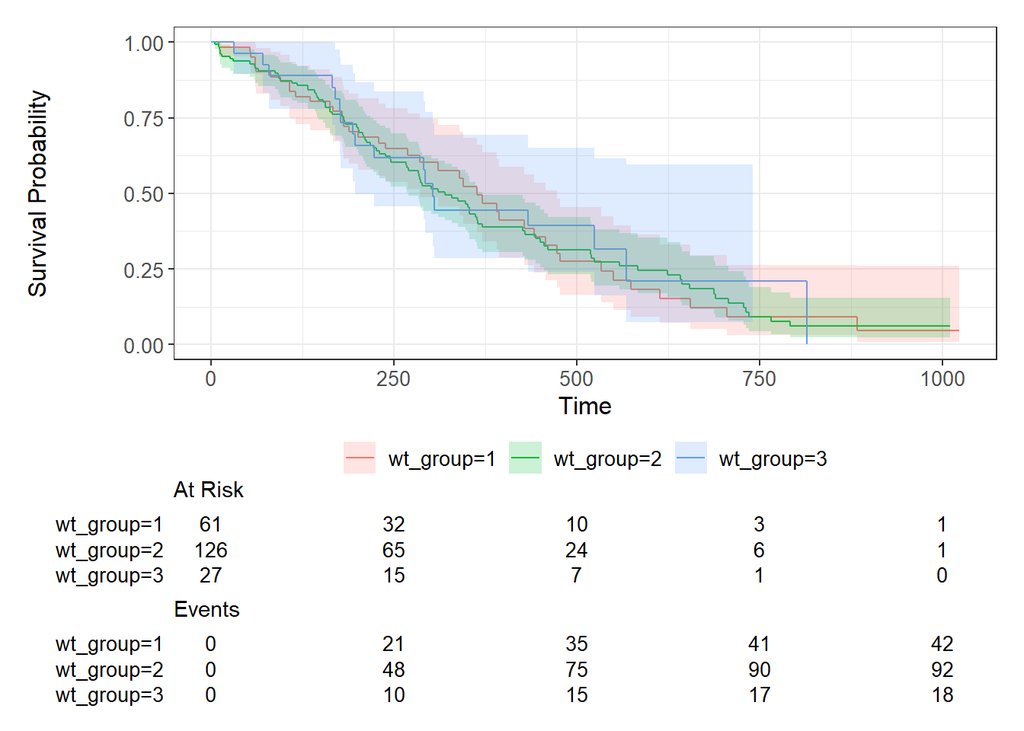

```r
cancer <- cancer %>%
  mutate(wt_group = cut(wt.loss,
                        breaks = c(-Inf, 0, 25, Inf),
                        labels = c(1, 2, 3)))
sfit_wt <- survfit(Surv(time, status) ~ wt_group, data = cancer)

ggsurvfit(sfit_wt) +
  add_confidence_interval() + add_risktable()
```

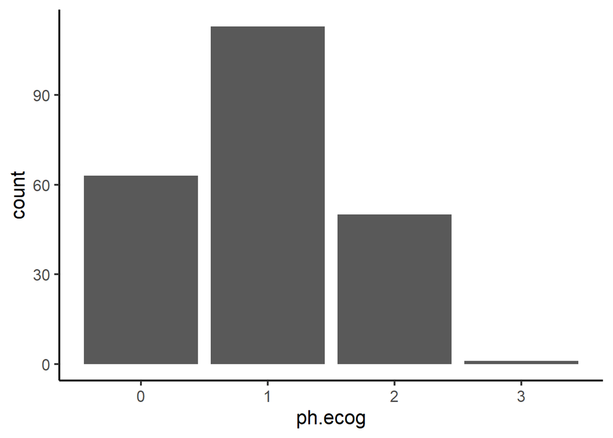

```r
ggplot(data = cancer, aes(x = ph.ecog)) +
  geom_bar()
```

```r
cox4 <- coxph(Surv(time, status) ~ ph.ecog, data = cancer)
summary(cox4)
```

```
Call:
coxph(formula = Surv(time, status) ~ ph.ecog, data = cancer)

  n= 227, number of events= 164
   (1 observation deleted due to missingness)

          coef exp(coef) se(coef)     z Pr(>|z|)
ph.ecog 0.4759    1.6095   0.1134 4.198 2.69e-05 ***
---
Signif. codes:  0 '***' 0.001 '**' 0.01 '*' 0.05 '.' 0.1 ' ' 1

        exp(coef) exp(-coef) lower .95 upper .95
ph.ecog      1.61     0.6213     1.289      2.01

Concordance= 0.604  (se = 0.024 )
Likelihood ratio test= 17.57  on 1 df,   p=3e-05
Wald test            = 17.62  on 1 df,   p=3e-05
Score (logrank) test = 17.89  on 1 df,   p=2e-05
```

```r
cox.zph(cox4)
```

```
        chisq df    p
ph.ecog  2.24  1 0.13
GLOBAL   2.24  1 0.13
```

```r
cancer <- cancer %>%
  mutate(ph.ecog_d0 = case_when(
    ph.ecog == 0 ~ 1,
    ph.ecog == 1 ~ 0,
    ph.ecog == 2 ~ 0,
    ph.ecog == 3 ~ 0))
cancer <- cancer %>%
  mutate(ph.ecog_d1 = case_when(
    ph.ecog == 0 ~ 0,
    ph.ecog == 1 ~ 1,
    ph.ecog == 2 ~ 0,
    ph.ecog == 3 ~ 0))
cancer <- cancer %>%
  mutate(ph.ecog_d2 = case_when(
    ph.ecog == 0 ~ 0,
    ph.ecog == 1 ~ 0,
    ph.ecog == 2 ~ 1,
    ph.ecog == 3 ~ 0))
cancer <- cancer %>%
  mutate(ph.ecog_d3 = case_when(
    ph.ecog == 0 ~ 0,
    ph.ecog == 1 ~ 0,
    ph.ecog == 2 ~ 0,
    ph.ecog == 3 ~ 1))

# 0 v 3, 1 v 3, 2 v 3
cox5 <- coxph(Surv(time, status) ~ ph.ecog_d0 + ph.ecog_d1 + ph.ecog_d2, data = cancer)
summary(cox5)
```

```
Call:
coxph(formula = Surv(time, status) ~ ph.ecog_d0 + ph.ecog_d1 +
    ph.ecog_d2, data = cancer)

  n= 227, number of events= 164
   (1 observation deleted due to missingness)

              coef exp(coef) se(coef)      z Pr(>|z|)
ph.ecog_d0 -2.2080    0.1099   1.0258 -2.152   0.0314 *
ph.ecog_d1 -1.8391    0.1590   1.0175 -1.808   0.0707 .
ph.ecog_d2 -1.2916    0.2748   1.0212 -1.265   0.2060
---
Signif. codes:  0 '***' 0.001 '**' 0.01 '*' 0.05 '.' 0.1 ' ' 1

           exp(coef) exp(-coef) lower .95 upper .95
ph.ecog_d0    0.1099      9.097   0.01472    0.8209
ph.ecog_d1    0.1590      6.291   0.02164    1.1678
ph.ecog_d2    0.2748      3.639   0.03714    2.0339

Concordance= 0.604  (se = 0.024 )
Likelihood ratio test= 18.44  on 3 df,   p=4e-04
Wald test            = 20.22  on 3 df,   p=2e-04
Score (logrank) test = 21.97  on 3 df,   p=7e-05
```

```r
cox.zph(cox5)
```

```
           chisq df    p
ph.ecog_d0 0.611  1 0.43
ph.ecog_d1 0.287  1 0.59
ph.ecog_d2 2.033  1 0.15
GLOBAL     4.876  3 0.18
```

```r
# 0 v 1, 0 v 2, 0 v 3
cox6 <- coxph(Surv(time, status) ~ ph.ecog_d1 + ph.ecog_d2 + ph.ecog_d3, data = cancer)
summary(cox6)
```

```
Call:
coxph(formula = Surv(time, status) ~ ph.ecog_d1 + ph.ecog_d2 +
    ph.ecog_d3, data = cancer)

  n= 227, number of events= 164
   (1 observation deleted due to missingness)

             coef exp(coef) se(coef)     z Pr(>|z|)
ph.ecog_d1 0.3688    1.4461   0.1987 1.857   0.0634 .
ph.ecog_d2 0.9164    2.5002   0.2245 4.081 4.48e-05 ***
ph.ecog_d3 2.2080    9.0973   1.0258 2.152   0.0314 *
---
Signif. codes:  0 '***' 0.001 '**' 0.01 '*' 0.05 '.' 0.1 ' ' 1

           exp(coef) exp(-coef) lower .95 upper .95
ph.ecog_d1     1.446     0.6915    0.9797     2.134
ph.ecog_d2     2.500     0.4000    1.6101     3.883
ph.ecog_d3     9.097     0.1099    1.2182    67.937

Concordance= 0.604  (se = 0.024 )
Likelihood ratio test= 18.44  on 3 df,   p=4e-04
Wald test            = 20.22  on 3 df,   p=2e-04
Score (logrank) test = 21.97  on 3 df,   p=7e-05
```

```r
cox.zph(cox6)
```

```
           chisq df     p
ph.ecog_d1 0.287  1 0.592
ph.ecog_d2 2.033  1 0.154
ph.ecog_d3 2.779  1 0.096
GLOBAL     4.876  3 0.181
```

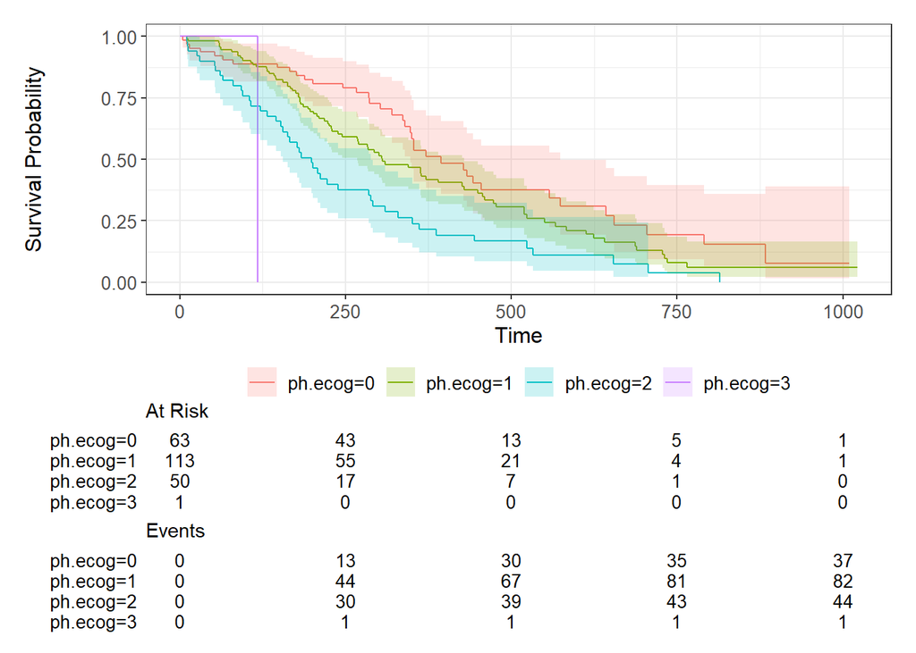

```r
sfit_ph.ecog <- survfit(Surv(time, status) ~ ph.ecog, data = cancer)
ggsurvfit(sfit_ph.ecog) +
  add_confidence_interval() + add_risktable()
```